# Practical Machine Learning Assignment

## Introduction

In this study motion sensors were attached to six healthy young volunteers to detect their movements during exercise. The sensors were at the right wrist, right elbow, center of waist and on the dumbell itself.

The dataset was collected during one set of 10 repetitions of the Unilateral Dumbbell Biceps Curl in five different fashions:

1. exactly according to the specification (Class A)
2. throwing the elbows to the front (Class B)
3. lifting the dumbbell only halfway (Class C)
4. lowering the dumbbell only halfway (Class D)
5. throwing the hips to the front (Class E).

The aim of this study was to develop a machine learning algorithm that could accurately detect each of these five conditions.

## Methods

### Download and Clean Data

#### Download Data

The data was downloaded from the website (http://groupware.les.inf.puc-rio.br/har) using the code below:

```r
setwd("~/Google Drive/Coursera/Data Analysis/Practical machine learning")
url1 = "https://d396qusza40orc.cloudfront.net/predmachlearn/pml-training.csv"
url2 = "https://d396qusza40orc.cloudfront.net/predmachlearn/pml-testing.csv"
download.file(url1,"pml-training.csv",method="curl")
download.file(url2,"pml-testing.csv",method="curl")
```

#### Load Data

Next the data was read into RStudio.

```r
train <- read.table("pml-training.csv",header=TRUE,as.is = "numeric", sep=",")
test <- read.table("pml-testing.csv",header=TRUE,as.is = "numeric", sep=",")
```

#### Inspect Data

Next, the data was examined.

```r
summary(train)
```

[output not shown]

#### Clean Data

##### Remove Missing Data

Many of the columns contained little or no data, so they were removed using the code below. This left 1 predictor variable (classe), and 52 predictor variables.

```r
train[train ==""] <- NA
present <- train[colSums(!is.na(train)) > 1000] # (Reference 1).
```

##### Remove Unnecessary Data

Columns with order, name and time data were removed. The order, in particular, was sequential and could confuse our algorithm.

```r
training <- present[,-c(1,2,3,4,5,6,7)]
```

I used the caret package for the processing and analysis of the data (References 2, 3). The training dataset contained 19622 observations, so 60% was split into a training set (11776 observations). The remaining 40% was split equally between a testSet and a validationSet (3923 observations each). I used the createDataPartition function from the caret package for this purpose.

```r
library(caret)
inTrain <- createDataPartition(y=training$classe,p=0.6,list=FALSE)
trainSet <- training[inTrain,]
testing <- training[-inTrain,]
inTest <- createDataPartition(y=testing$classe, p=0.5,list=FALSE)
testSet <- testing[inTest,]
validationSet <- testing[-inTest,]
```

I confirmed that each dataset contained a similar proportion of each of the five outcomes.

```r
summary(train$classe)/nrow(train)
```

```
##      A      B      C      D      E
## 0.2844 0.1935 0.1744 0.1639 0.1838
```

```r
summary(training$classe)/nrow(training)
```

```
##      A      B      C      D      E
## 0.2844 0.1935 0.1744 0.1639 0.1838
```

```r
summary(testing$classe)/nrow(testing)
```

```
##      A      B      C      D      E
## 0.2845 0.1935 0.1744 0.1639 0.1838
```

### Explore Data

Next the data was examined using boxplots for any obvious patterns. Although some of the variables had slightly higher or lower means for the different outcomes, these differences were not very marked. Visually about 18 of the variables looked as if the might help in separating out 1-2 of the variables.

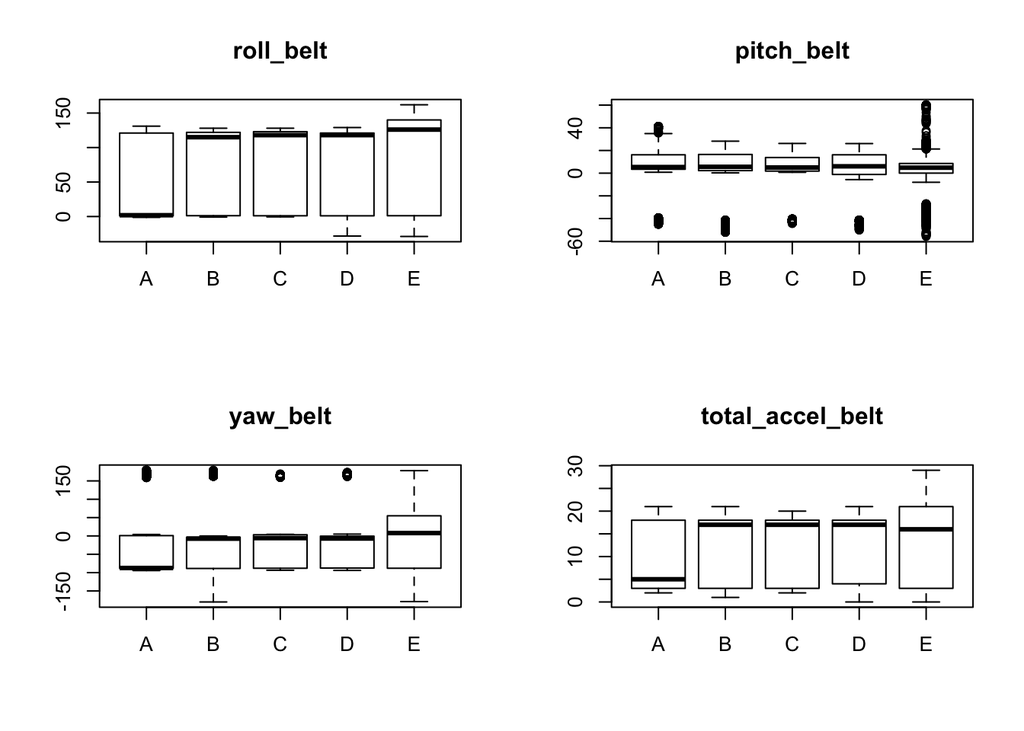

### Model Development

There are 150 approaches for developing models in the (Reference 4). Since this was a classification task, I tried the random forest method first, partly since Jeff had recommended it so highly in the lectures.

I chose the train control parameters after reading reference 2. The most important selection was the method of error detection using out-of-bag error. Many permutations of these parameters were tried, with this being the most effective.

```r
set.seed(47) # ensure accurate comparison through multiple trials
tc <- trainControl("oob", number=10, repeats=10, classProbs=TRUE, savePred=T)
rfFit <- train(classe~.,method="rf",data=trainSet,prox=TRUE,trControl = tc)
rfFit
```

```
## Random Forest
##
## 11776 samples
##    52 predictors
##     5 classes: 'A', 'B', 'C', 'D', 'E'
##
## No pre-processing
## Resampling: Out of Bag Resampling
##
## Summary of sample sizes:
##
## Resampling results across tuning parameters:
##
##   mtry  Accuracy  Kappa
##   2     1         1
##   30    1         1
##   50    1         1
##
## Accuracy was used to select the optimal model using  the largest value.
## The final value used for the model was mtry = 2.
```

### Cross-Validation of Model

The data was crossvalidated against both the testSet and the validationSet prepared earlier. Confusion matrices were produced, which suggested that the model worked robustly on these two additional datasets.

#### Test Set

```r
pred <- predict(rfFit,newdata=testSet)
confusionMatrix(pred,testSet$classe)
```

```
## Confusion Matrix and Statistics
##
##           Reference
## Prediction    A    B    C    D    E
##          A 1114    1    0    0    0
##          B    1  754   10    0    0
##          C    0    4  674   12    0
##          D    0    0    0  631    1
##          E    1    0    0    0  720
##
## Overall Statistics
##
##                Accuracy : 0.992
##                  95% CI : (0.989, 0.995)
##     No Information Rate : 0.284
##     P-Value [Acc > NIR] : <2e-16
##
##                   Kappa : 0.99
##  Mcnemar's Test P-Value : NA
##
## Statistics by Class:
##
##                      Class: A Class: B Class: C Class: D Class: E
## Sensitivity             0.998    0.993    0.985    0.981    0.999
## Specificity             1.000    0.997    0.995    1.000    1.000
## Pos Pred Value          0.999    0.986    0.977    0.998    0.999
## Neg Pred Value          0.999    0.998    0.997    0.996    1.000
## Prevalence              0.284    0.193    0.174    0.164    0.184
## Detection Rate          0.284    0.192    0.172    0.161    0.184
## Detection Prevalence    0.284    0.195    0.176    0.161    0.184
## Balanced Accuracy       0.999    0.995    0.990    0.991    0.999
```

#### Validation Set

```r
pred <- predict(rfFit,newdata=validationSet)
confusionMatrix(pred,validationSet$classe)
```

```
## Confusion Matrix and Statistics
##
##           Reference
## Prediction    A    B    C    D    E
##          A 1115   12    0    0    0
##          B    1  746    6    0    0
##          C    0    1  678    9    0
##          D    0    0    0  634    0
##          E    0    0    0    0  721
##
## Overall Statistics
##
##                Accuracy : 0.993
##                  95% CI : (0.989, 0.995)
##     No Information Rate : 0.284
##     P-Value [Acc > NIR] : <2e-16
##
##                   Kappa : 0.991
##  Mcnemar's Test P-Value : NA
##
## Statistics by Class:
##
##                      Class: A Class: B Class: C Class: D Class: E
## Sensitivity             0.999    0.983    0.991    0.986    1.000
## Specificity             0.996    0.998    0.997    1.000    1.000
## Pos Pred Value          0.989    0.991    0.985    1.000    1.000
## Neg Pred Value          1.000    0.996    0.998    0.997    1.000
## Prevalence              0.284    0.193    0.174    0.164    0.184
## Detection Rate          0.284    0.190    0.173    0.162    0.184
## Detection Prevalence    0.287    0.192    0.175    0.162    0.184
## Balanced Accuracy       0.997    0.990    0.994    0.993    1.000
```

### Prediction of 20 cases

Finally, it was time to try out the model on the 20 “left out” cases. The results were then uploaded to the Coursera website for autograding.

#### Predict Results

```r
answers <- predict(rfFit,newdata=test)
answers
```

```
##  [1] B A B A A E D B A A B C B A E E A B B B
## Levels: A B C D E
```

#### Create Files to submit

I used the function supplied in the instructions to create the submission files and save these in the Results folder.

```r
pml_write_files = function(x){
  n = length(x)
  for(i in 1:n){
    filename = paste0("Results/problem_id_",i,".txt")
    write.table(x[i],file=filename,quote=FALSE,row.names=FALSE,col.names=FALSE)
  }
}
pml_write_files(answers)
```

## Results

The answers files were submitted for autograding. All 20 predictions were correct.

## Conclusions

I was surprised (and gratified) by how accurately the final model worked. There were many false trails along the way. I felt that I learned a huge amount from this project about both the practical application of these techniques to a messy dataset, and also about managing a data analysis project.

## References

1. http://stackoverflow.com/questions/7330915/removing-columns-with-missing-values
2. Building Predictive Models in R Using the caret Package. Max Kuhn. Journal of Statistical Software November 2008, Volume 28, Issue 5
3. http://en.wikipedia.org/wiki/Random_forest Random Forest article on Wikipedia
4. http://caret.r-forge.r-project.org/modelList.html